# Organize field data with the jabotR field notebook

Here we present a complete guide to `jabot_fieldbook()`, the interactive field notebook distributed with the `jabotR` package. Unlike the other `jabotR` functions, which query the JABOT web service, the field notebook is a self-contained tool for organizing new collection data in the field and turning it into a spreadsheet ready for submission to JABOT.

## Function Overview

`jabot_fieldbook()` opens the field notebook, built with plain HTML, CSS and JavaScript, in the user’s default web browser. It runs entirely offline, requires neither Shiny nor an internet connection, and performs all spreadsheet generation locally in the browser — no data ever leaves the user’s computer. The interface is available in Portuguese (the default) and English, with a language switch in the bottom-left corner.

[figure not shown]

## Arguments

| Argument | Description |
| --- | --- |
| `browser` | Logical. If `TRUE` (default), opens the field notebook in the default web browser. If `FALSE`, the application is not opened and only its local path is returned. |

## Opening the Field Notebook

```r
jabot_fieldbook()
```

To retrieve the local path to the application (for example, to open it manually or embed it elsewhere) without launching a browser tab:

```r
app_path <- jabot_fieldbook(browser = FALSE)
app_path
```

## How Data Are Organized

The field notebook is built around **collection events**. A collection event represents a single collecting date/locality combination — the equivalent of one field-notebook entry — and groups together:

- One shared **header**, entered once and reused by every specimen collected during that event (date, country, state, municipality, locality, protected area, habitat, coordinates, altitude, and collector information).
- One or more **specimens**, each with its own taxonomic and specimen-level data (collection number, family, genus, species, determiner, plant description, and other fields).

A running summary at the top of the page reports, in real time, the number of collection events, the number of specimens, the percentage of headers that are complete, and the fixed number of columns (58) in the JABOT spreadsheet format that the tool exports to.

Click **Add collection event** to start a new event, or use **Repeat previous header** / **Duplicate header** inside an existing event to reuse locality and date information across nearby collecting events without retyping it.

### Header fields

| Field | Description |
| --- | --- |
| Day / Month / Year | Collection date. |
| Country, State, Municipality | Political divisions where the collection took place. |
| Locality | Locality within the municipality (farm, river, road, community, etc.). |
| Protected area (UC / TI) | Conservation unit, Indigenous Territory, or other protected area. |
| Habitat | Description of the specimen’s habitat. |
| Latitude / Longitude | Coordinates in decimal degrees. |
| Altitude | Minimum altitude or depth. |
| Collector / Additional collectors | Main collector and any additional collectors. |
| Locality notes | Free-text notes about the collecting locality. |

An **Advanced header fields** panel exposes further, less frequently needed columns: coordinates split into degrees/minutes/seconds with N/S and E/W hemisphere, maximum altitude and its unit, the source herbarium acronym, duplicate herbaria and their count, and the associated project.

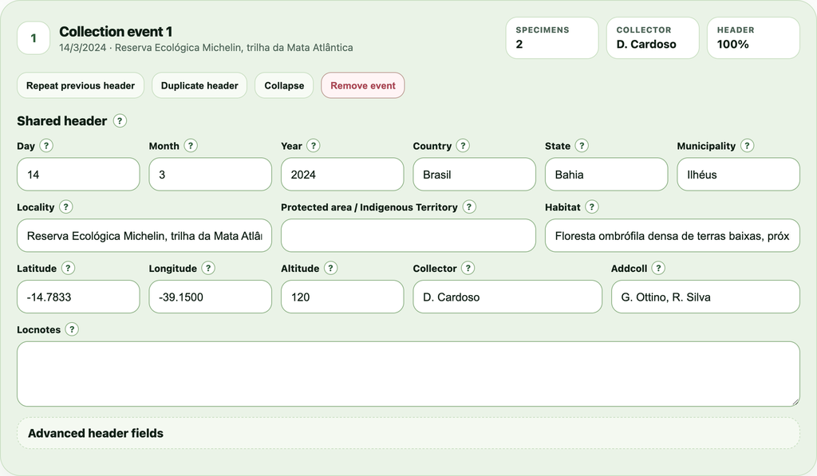

A collection event with its shared header filled in — date, locality, coordinates, habitat, and collectors

### Specimen fields

Each row of the specimen table covers the fields needed for a quick first pass — collection number, family, genus, `cf.` qualifier, species epithet, determiner, determination date, and a free-text plant description. Column widths can be adjusted directly in the table.

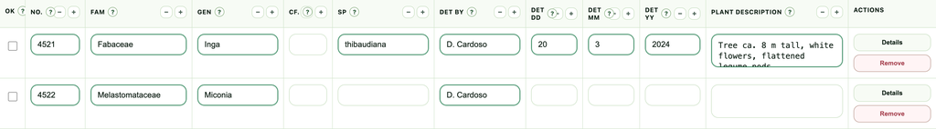

The specimen table for a collection event, with the Details and Remove actions for each row

Opening **Details** on a specimen reveals the complete record, organized into four groups:

| Group | Fields |
| --- | --- |
| Taxonomic identification | Family, genus, `cf.`, species 1–3 with authors and infraspecific ranks, vernacular name |
| Collection and determination | Number, determiner, determination date |
| Individual description | Plant description |
| Uses and notes | Uses, specific use |

The notebook form shows only the fields most useful in the field. The remaining JABOT columns (`typestat`, `numtombo`, `sufixo`, `flor`, `fruto`, `fuste`, `altura`, `unidmedaltura`, `habito`) are not shown, but they are always included — empty — in the exported JABOT spreadsheet, which keeps its full 58-column layout.

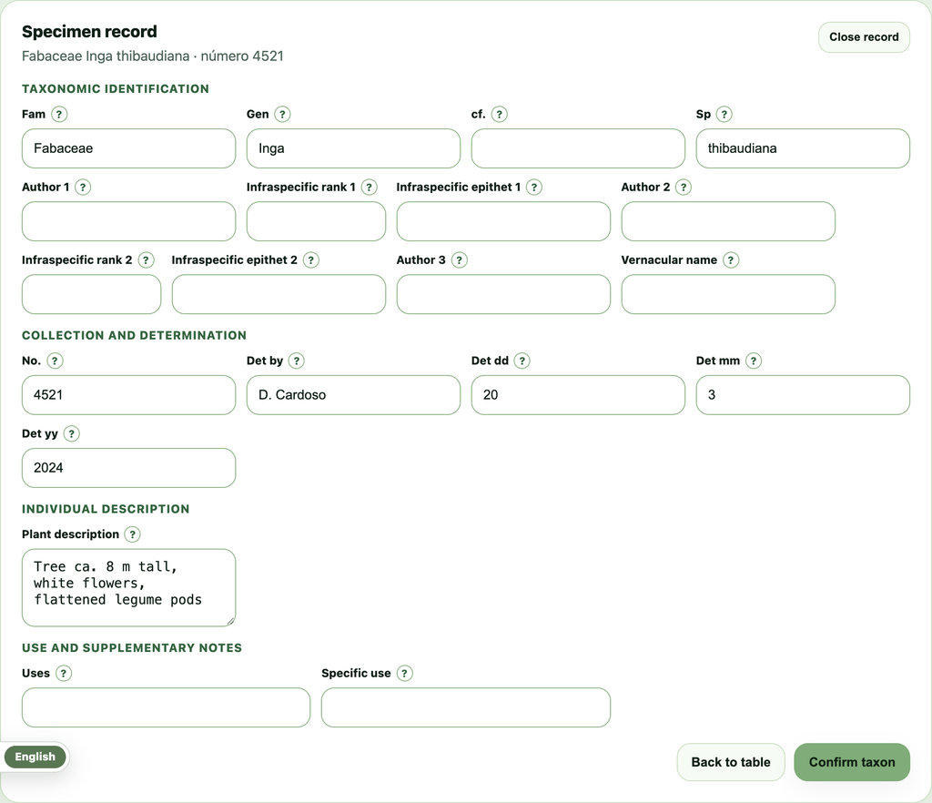

The specimen “Details” record, with its four field groups: taxonomic identification, collection and determination, individual description, and uses/notes

Use **Add specimen** to add a new row, **Duplicate last** to copy the previous specimen as a starting point, or **Continue number sequence** to auto-increment the collection number for a new specimen.

## Reviewing Before Export

A validation panel checks the data as it is entered and flags, per collection event, issues such as an incomplete collection date, a missing collector, an event with no specimens, or a specimen missing its collection number or any taxonomic information (at least family, genus, or species). Review the flagged items before exporting; the spreadsheet can still be generated with warnings pending if needed.

## Saving and Loading Drafts

- **Save draft** stores the current state of the notebook in the browser’s local storage, so work in progress is not lost if the tab is closed.
- **Load draft** restores the most recently saved draft.

Drafts are kept locally in the browser being used and are not synced across devices or browsers — save a draft again after significant changes, and avoid clearing browser site data before exporting.

## Exporting

Three export options are available, at the top and bottom of the page:

- **Download empty spreadsheet**: generates a blank spreadsheet with the 58 JABOT columns and no data, useful as a template or for entering data directly in a spreadsheet application.
- **Generate Jabot spreadsheet**: exports all completed collection events and specimens as a single spreadsheet in the standard JABOT column layout, ready for submission.
- **Generate field notebook (PDF)**: renders a printable field notebook from the entered data, useful as a physical or archival record of the collecting trip.

### The printable field notebook

The PDF opens with the main collector’s name as a large title, with the range of collection numbers below it. Each collecting date follows in green, then one line with the locality in the form `COUNTRY: State, Municipality, Locality, protected area, locality notes, habitat, coordinates`, and the additional collectors, if any. The collector is not repeated for each event (only if it differs from the main collector). Each specimen is a single line: collection number, family, scientific name (in italics) and the plant description, followed by any other information entered for the specimen, such as vernacular name, uses and specific use.

[figure not shown]

Printable field notebook (PDF): main collector as the title, collection-number range, dated collecting events with their locality, and one line per specimen

## See Also

- `jabot_records()`: Retrieve and filter existing JABOT specimen records
- `jabot_summary()`: Get a summary of JABOT collections